# Coronavirus v Čechách

# Základní statistiky

## Testy

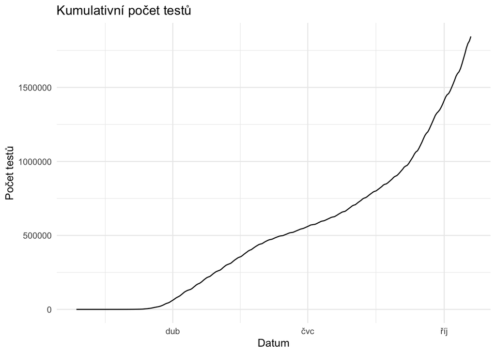

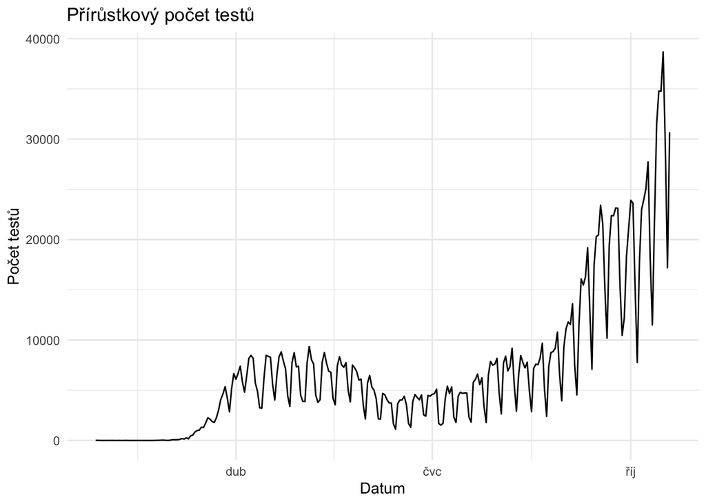

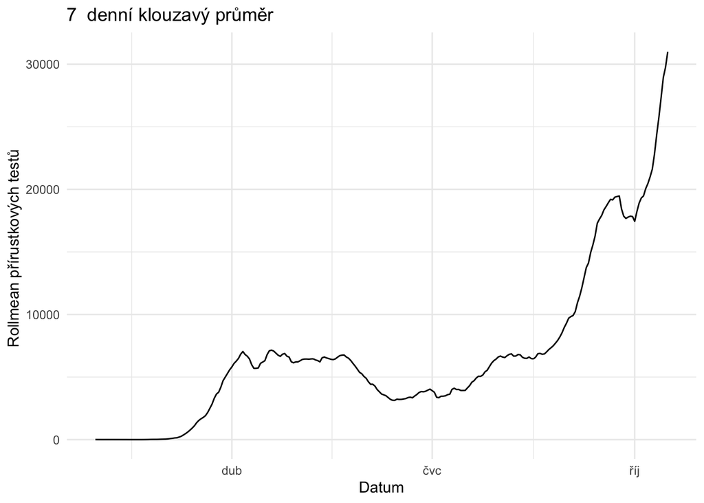

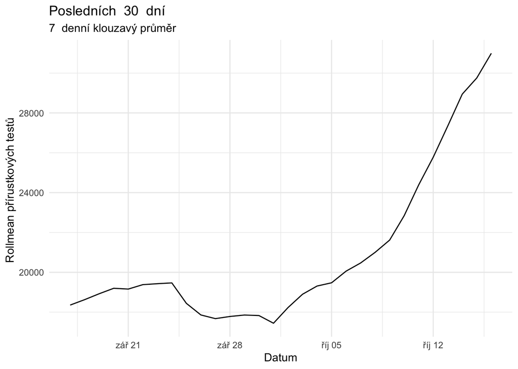

## Pozitivní případy

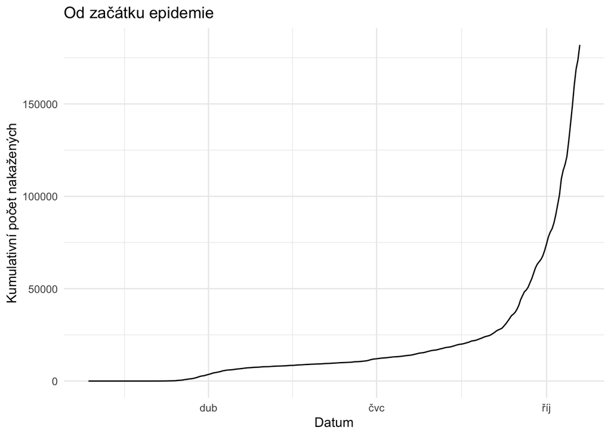

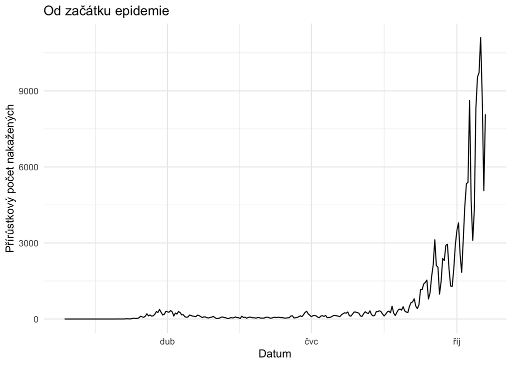

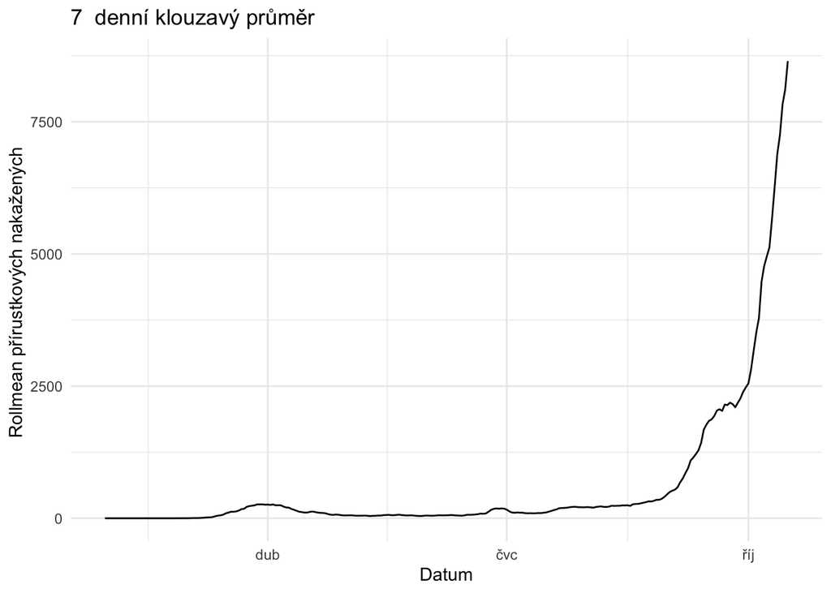

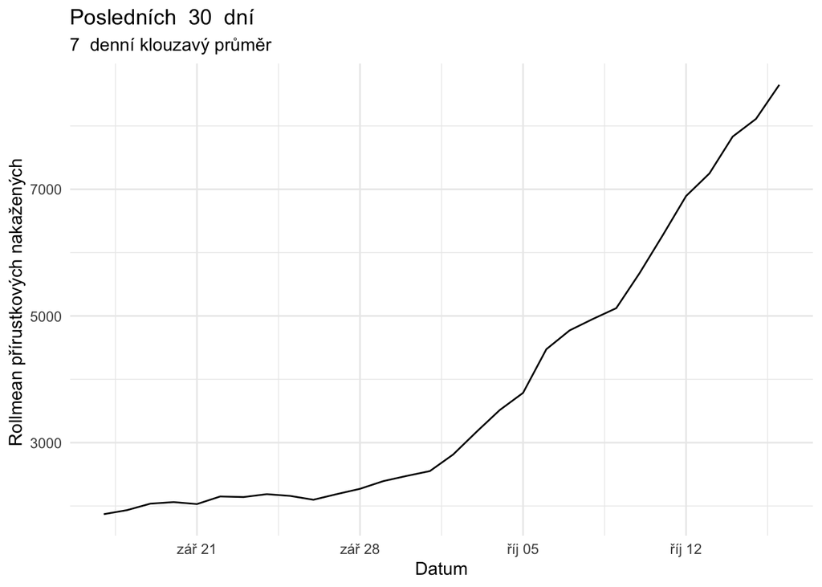

## Podíl pozitivních testů

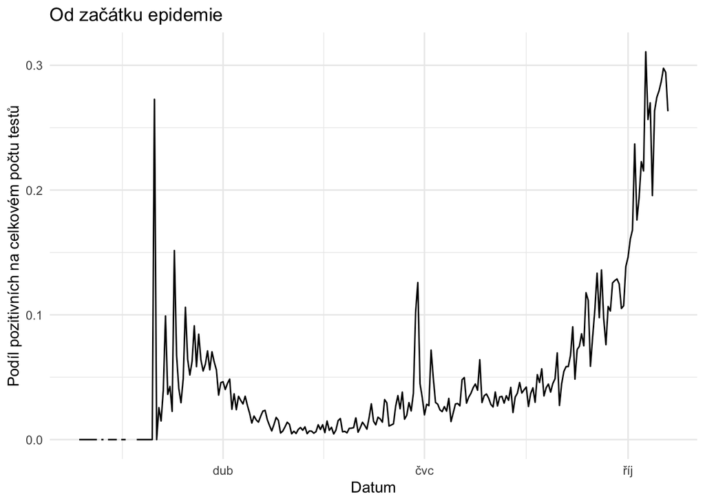

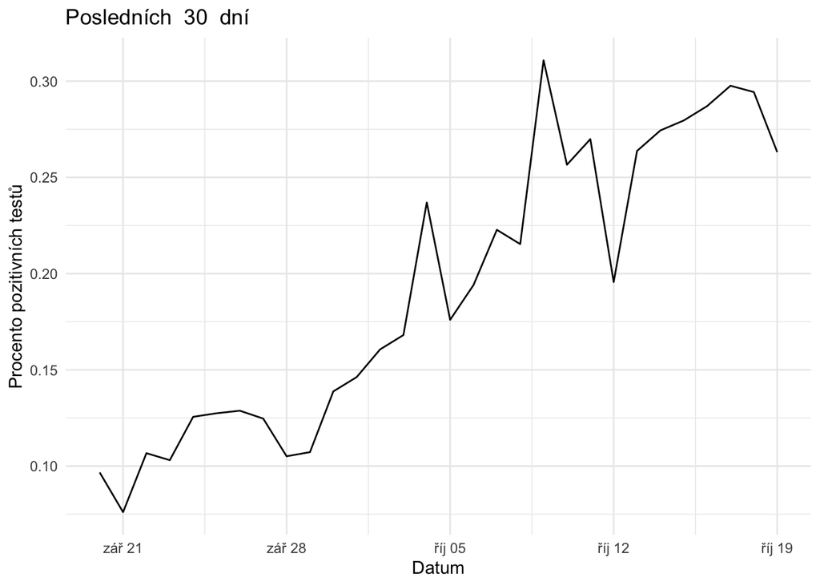

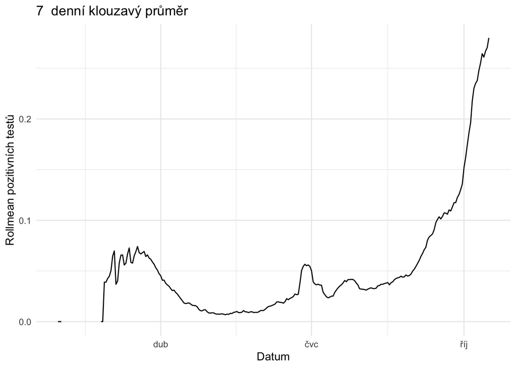

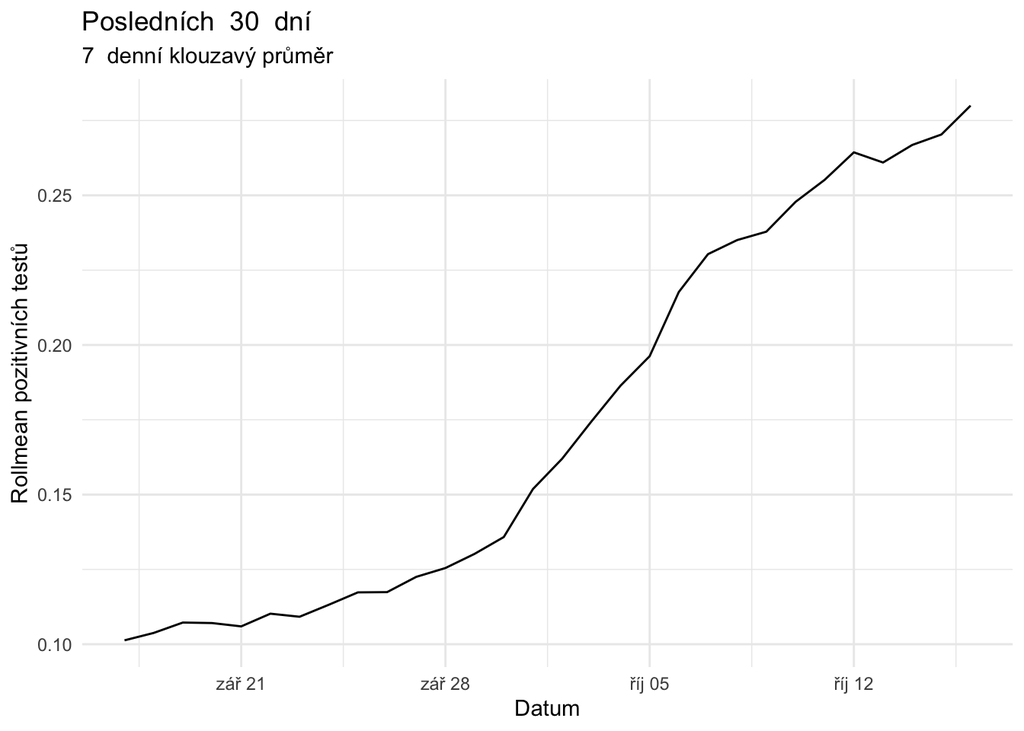

Podíl pozitivních testů na celkovém počtu od začátku epidemie je `9.863` %.

Podíl pozitivních testů na celkovém počtu za posledních 30 dní je `20.421` %.

# Modely

## Linearní model

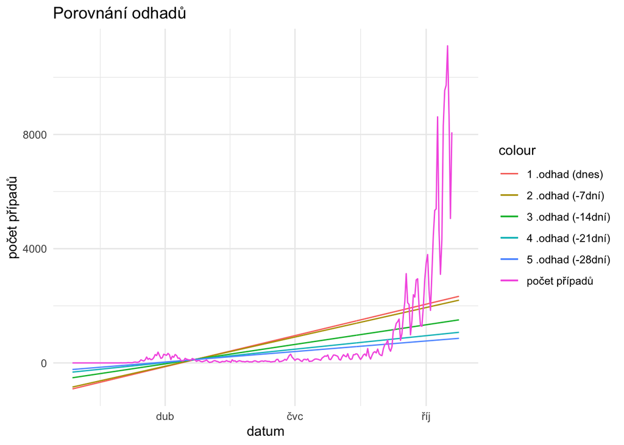

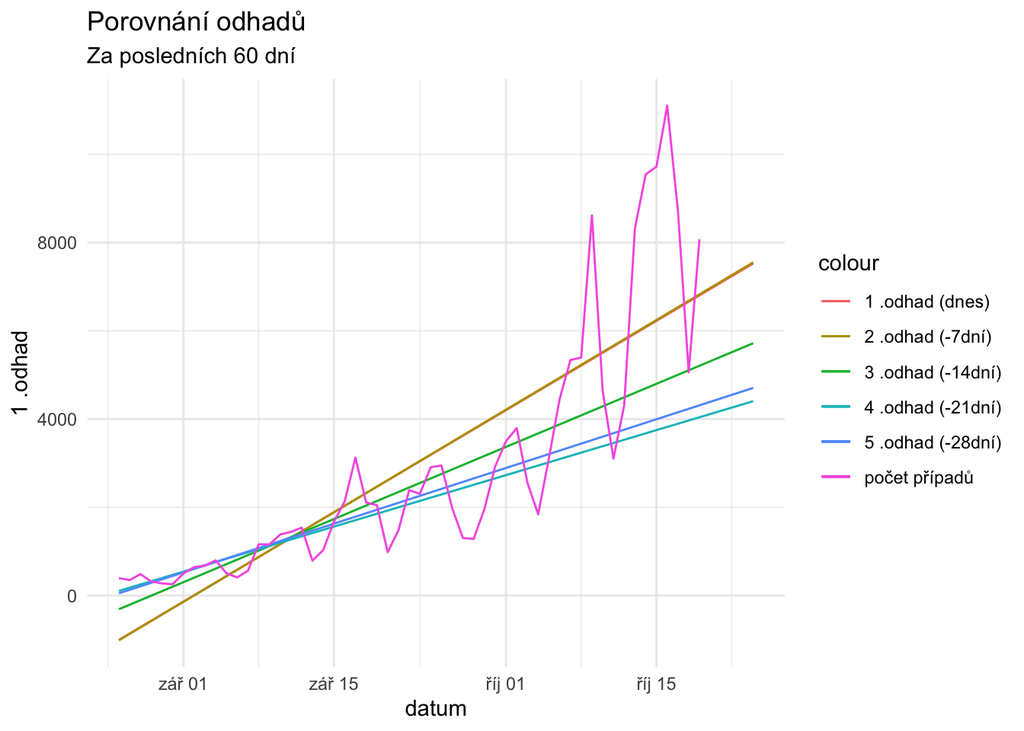

### Data (Lineární model)

#### Od začátku epidemie

Podle lineárního modelu bychom tímto tempem měli dne `2020-10-24` podle

- 1. odhadu `2333` nakažených denně
- 2. odhadu `2198` nakažených denně
- 3. odhadu `1508` nakažených denně
- 4. odhadu `1072` nakažených denně
- 5. odhadu `861` nakažených denně

#### Za posledních `60` dní

Podle lineárního modelu bychom tímto tempem měli dne `2020-10-24` podle

- 1. odhadu `7526` nakažených denně
- 2. odhadu `7553` nakažených denně
- 3. odhadu `5719` nakažených denně
- 4. odhadu `4405` nakažených denně
- 5. odhadu `4705` nakažených denně

## Kvadratický model

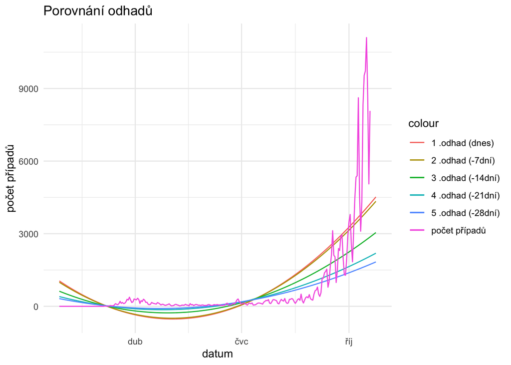

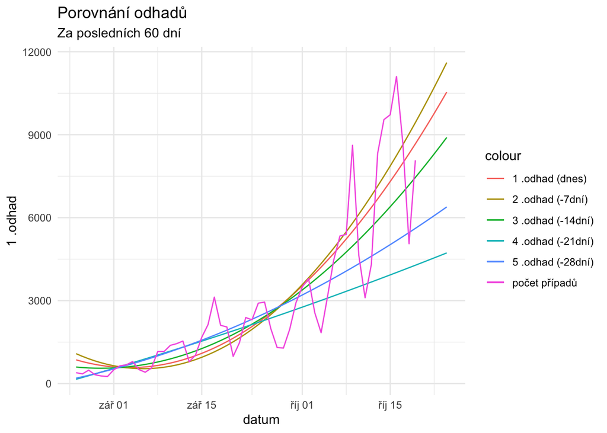

### Data (Kvadratický model)

#### Od začátku epidemie

Podle kvadratického modelu bychom tímto tempem měli dne `2020-10-24` podle

- 1. odhadu `4518` nakažených denně
- 2. odhadu `4338` nakažených denně
- 3. odhadu `3047` nakažených denně
- 4. odhadu `2194` nakažených denně
- 5. odhadu `1834` nakažených denně

#### Za posledních `60` dní

- 1. odhadu `10543` nakažených denně
- 2. odhadu `11608` nakažených denně
- 3. odhadu `8900` nakažených denně
- 4. odhadu `4725` nakažených denně
- 5. odhadu `6388` nakažených denně

# SIR MODELY

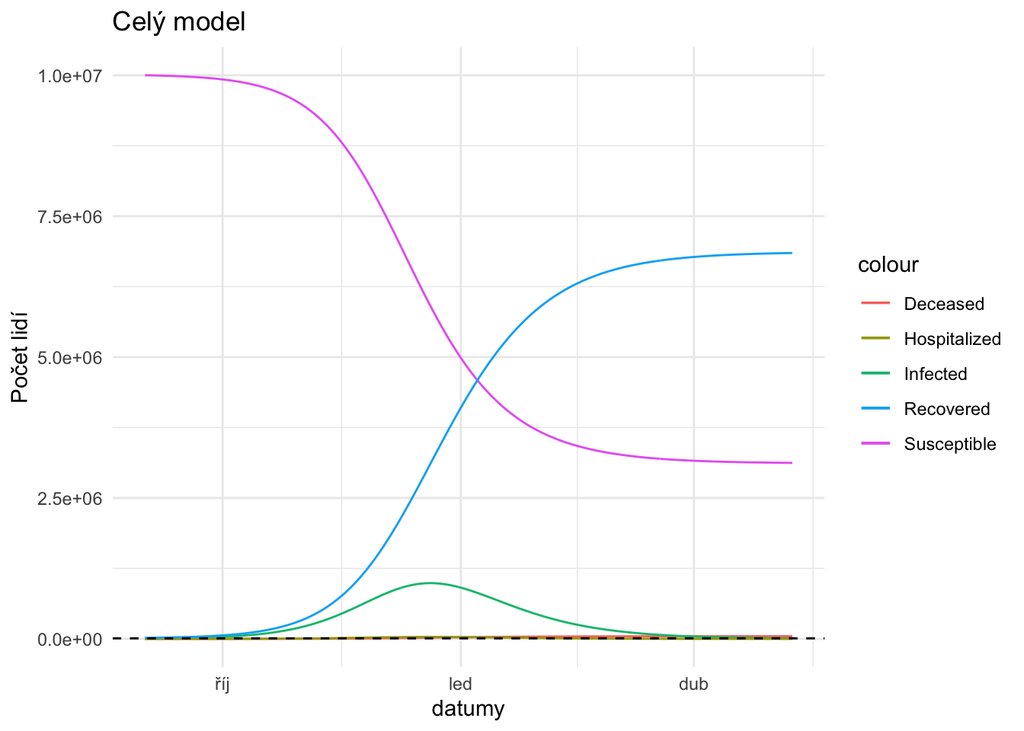

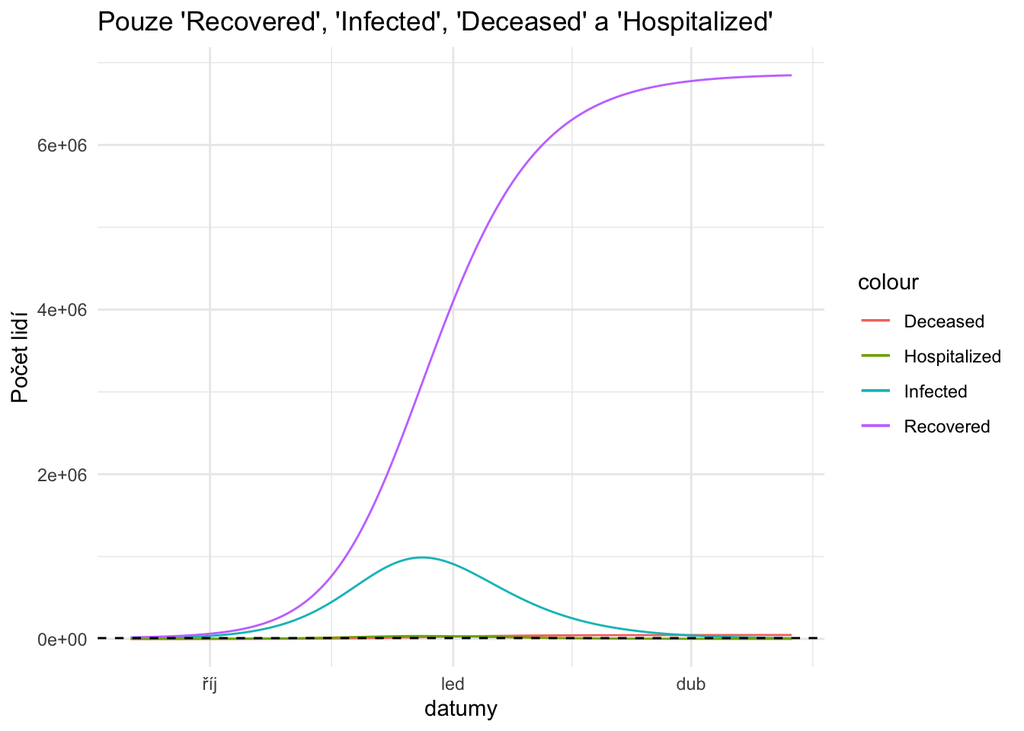

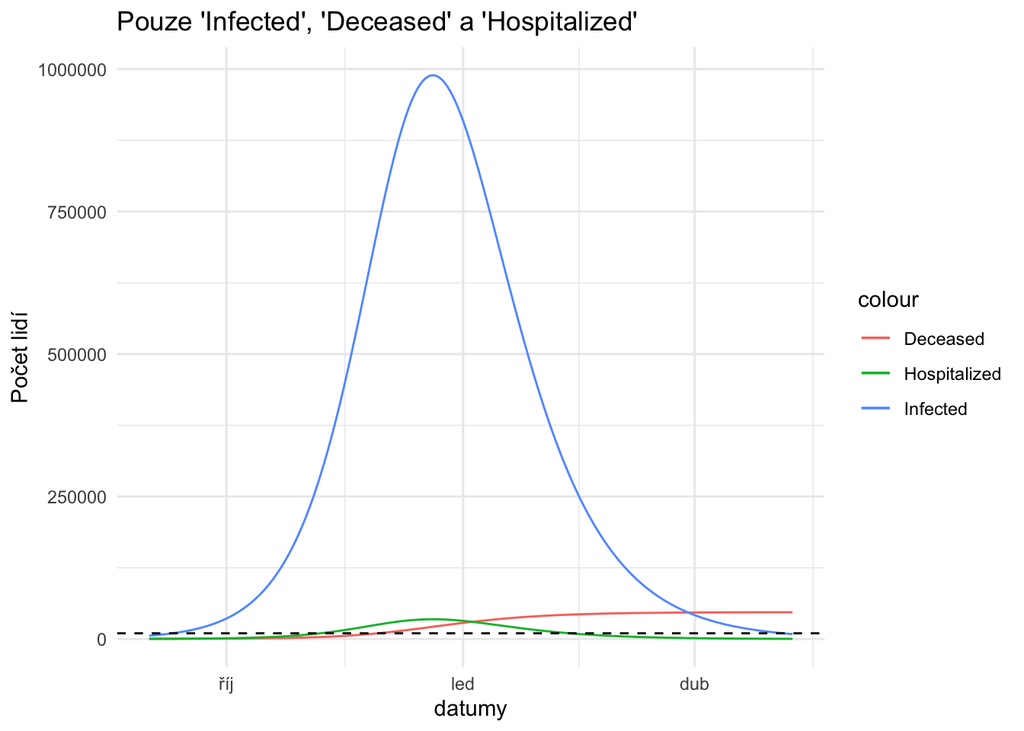

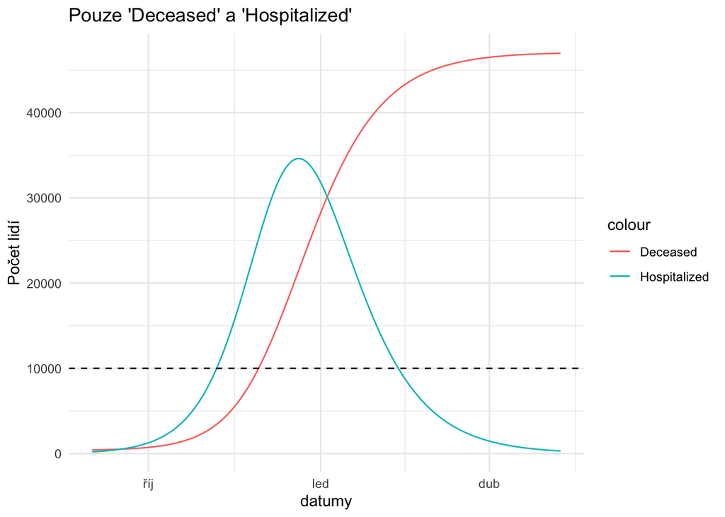

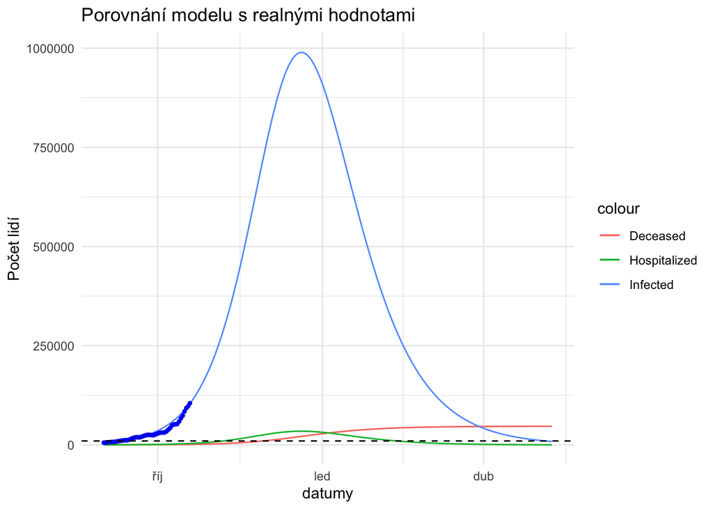

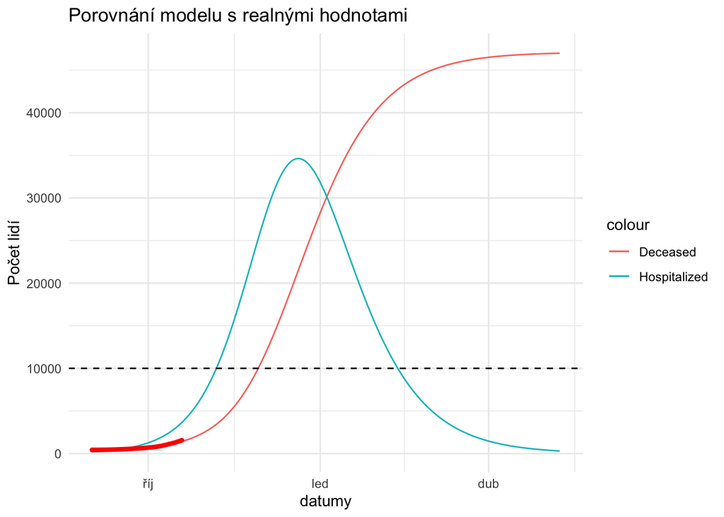

## Informace

`Peak nastane dne 2020-12-20 s počtem nakažených rovnu 989166 a aktuálním počtem hospitalizovných v nemocnicích 34621 lidí.`

`Kapacita nemocnic, která je stanovena na 10000 lůžek, bude při momentálním trendu překročena dne 2020-11-07`

`Celkově Covid-19 prodělá 6846520`

`Počet umrtí se zastaví na čísle 46980`

# Informace

Poslední update proběhl `2020-10-19` ze stránek ministerstva zdravotnictví ČR (https://onemocneni-aktualne.mzcr.cz/covid-19)